# Tugas Pertemuan 2 - Penanganan Autokorelasi

Restu Ramadhani_M0401241047

2026-09-02

# Pemanggilan Library

```r
library(dplyr)
library(TTR)
library(forecast)
library(lmtest) #digunakan untuk uji formal pendeteksian autokorelasi
library(orcutt) #untuk membuat model regresi Cochrane-Orcutt
library(HoRM) #untuk membuat model regresi Hildreth-Lu
library(readxl)
library(lmtest)
```

# Data 1 - Market Share

```r
library(readxl)

data1 <- read_excel("D:/IPB/PPT Kuliah - IPB/Semester 5 Dept Statistika/MPDW/Dataset/Dataset Praktikum 2.xlsx",sheet = "Market")
data1
```

```
## # A tibble: 20 × 3
##    Period `Market share` Price
##     <dbl>          <dbl> <dbl>
##  1      1           3.63  0.97
##  2      2           4.2   0.95
##  3      3           3.33  0.99
##  4      4           4.54  0.91
##  5      5           2.89  0.98
##  6      6           4.87  0.9
##  7      7           4.9   0.89
##  8      8           5.29  0.86
##  9      9           6.18  0.85
## 10     10           7.2   0.82
## 11     11           7.25  0.79
## 12     12           6.09  0.83
## 13     13           6.8   0.81
## 14     14           8.65  0.77
## 15     15           8.43  0.76
## 16     16           8.29  0.8
## 17     17           7.18  0.83
## 18     18           7.9   0.79
## 19     19           8.45  0.76
## 20     20           8.23  0.78
```

# Eksplorasi Data

```r
# Summary
summary(data1)
```

```
##      Period       Market share       Price
##  Min.   : 1.00   Min.   :2.890   Min.   :0.7600
##  1st Qu.: 5.75   1st Qu.:4.787   1st Qu.:0.7900
##  Median :10.50   Median :6.490   Median :0.8300
##  Mean   :10.50   Mean   :6.215   Mean   :0.8520
##  3rd Qu.:15.25   3rd Qu.:7.982   3rd Qu.:0.9025
##  Max.   :20.00   Max.   :8.650   Max.   :0.9900
```

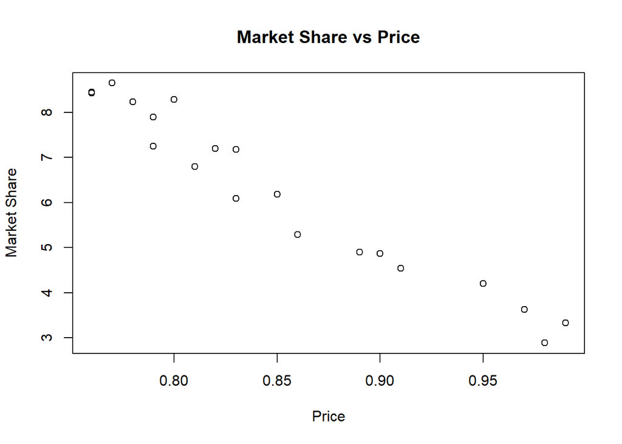

```r
# Scatterplot
plot(data1$Price, data1$`Market share`, main = "Market Share vs Price", xlab = "Price", ylab = "Market Share")
```

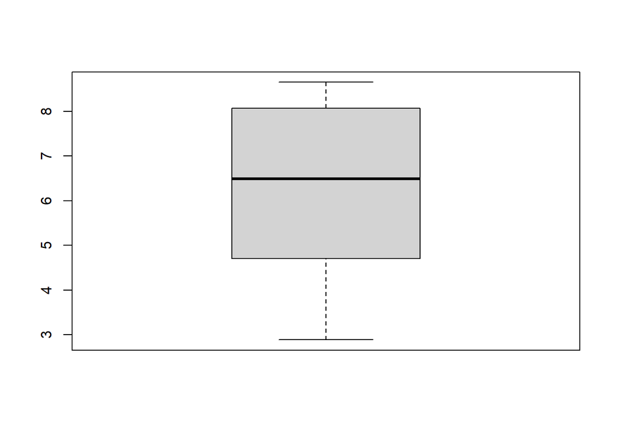

```r
# Boxplot
## Boxplot Market Share
boxplot(data1$`Market share`)
```

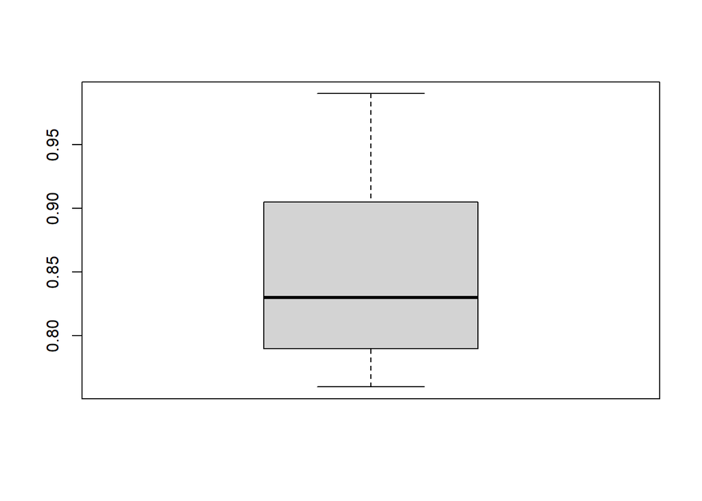

```r
## Boxplot Price
boxplot(data1$Price)
```

# Model Regresi

```r
model1 <- lm(`Market share`~Price, data = data1)
summary(model1)
```

```
##
## Call:
## lm(formula = `Market share` ~ Price, data = data1)
##
## Residuals:
##      Min       1Q   Median       3Q      Max
## -0.73068 -0.29764 -0.00966  0.30224  0.81193
##
## Coefficients:
##             Estimate Std. Error t value Pr(>|t|)
## (Intercept)   26.910      1.110   24.25 3.39e-15 ***
## Price        -24.290      1.298  -18.72 3.02e-13 ***
## ---
## Signif. codes:  0 '***' 0.001 '**' 0.01 '*' 0.05 '.' 0.1 ' ' 1
##
## Residual standard error: 0.4287 on 18 degrees of freedom
## Multiple R-squared:  0.9511, Adjusted R-squared:  0.9484
## F-statistic: 350.3 on 1 and 18 DF,  p-value: 3.019e-13
```

```r
names(data1)
```

```
## [1] "Period"       "Market share" "Price"
```

# Uji Asumsi

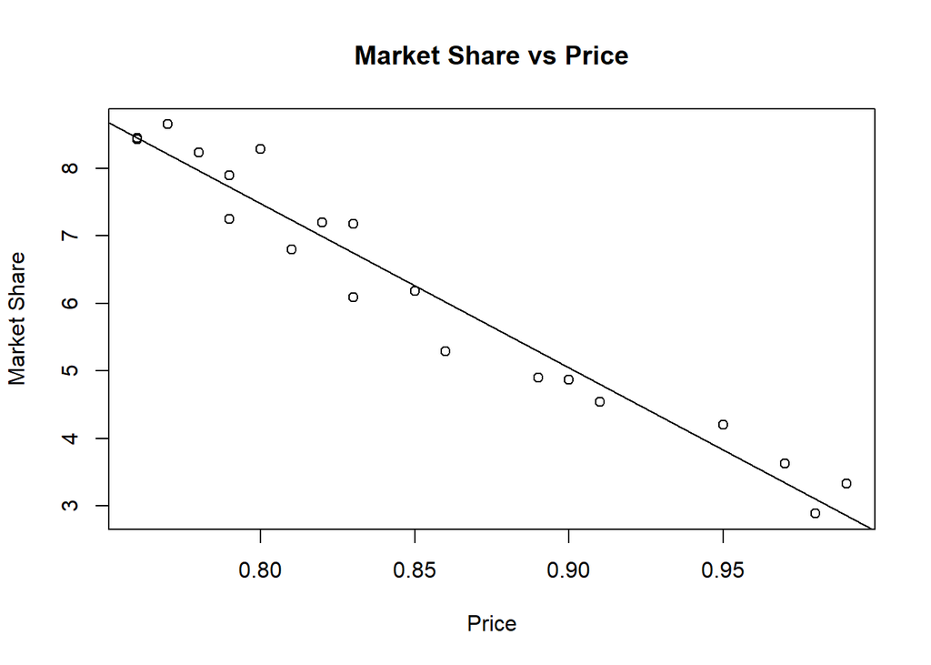

```r
# Linearitas
plot(data1$Price, data1$`Market share`, xlab = "Price", ylab = "Market Share", main = "Market Share vs Price")
abline(model1)
```

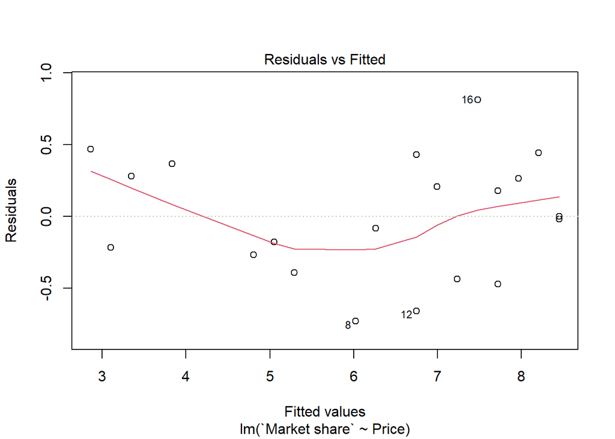

```r
plot(model1, which = 1)
```

Berdasarkan scatterplot Market Share vs Price, titik-titik pengamatan cenderung mengikuti pola garis lurus dengan arah linear yang negatif. Namun, pada grafik Residuals vs Fitted terlihat sedikit pola melengkung pada garis smoothing, yang menunjukkan adanya indikasi kecil penyimpangan dari linearitas.

```r
# Normalitas
shapiro.test(residuals(model1))
```

```
##
##  Shapiro-Wilk normality test
##
## data:  residuals(model1)
## W = 0.9744, p-value = 0.8437
```

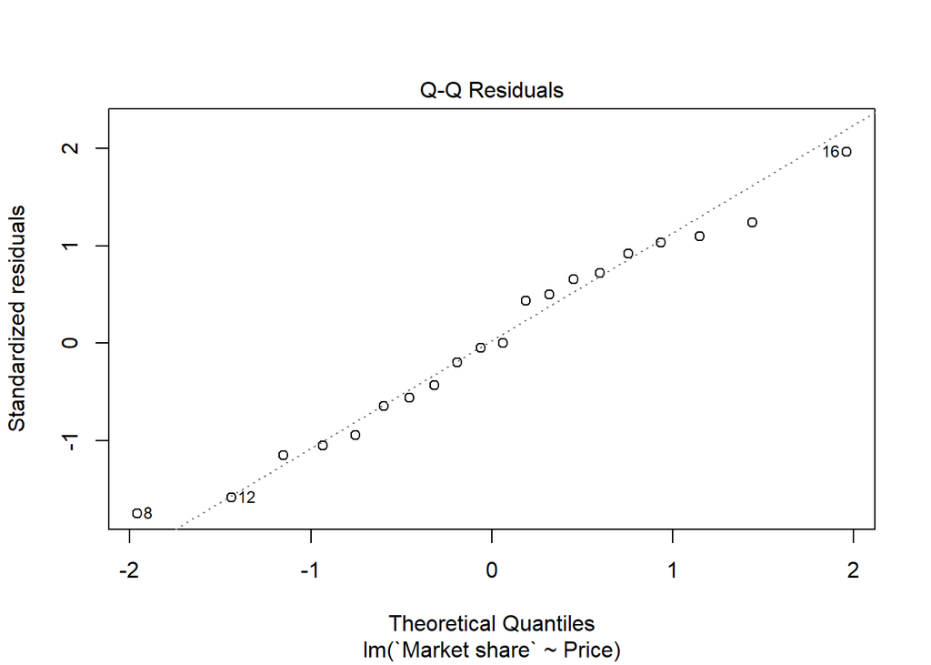

```r
plot(model1, which = 2)
```

Berdasarkan Shapiro Wilk test diperoleh nilai statistik W=0.9744 dengan p value sebesar 0.8437. Karena p value > 0.05, maka H0 gagal ditolak yang artinya asumsi normalitas tersebut terpenuhi dan didukung juga oleh grafik Normal Q-Q Plot yang menunjukkan bahwa titik-titik pengamatan cenderung mengikuti garis lurus.

```r
# Homoskedastisitas
bptest(model1)
```

```
##
##  studentized Breusch-Pagan test
##
## data:  model1
## BP = 0.11646, df = 1, p-value = 0.7329
```

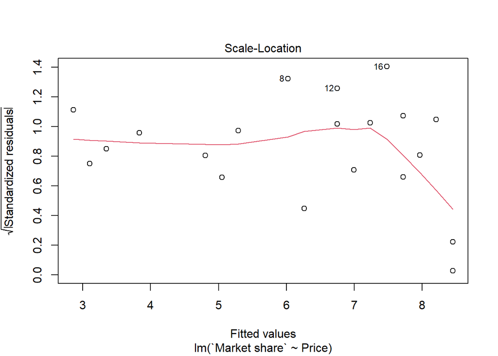

```r
plot(model1, which = 3)
```

Berdasarkan uji Breusch-Pagan diperoleh nilai statistik BP=0.11646 dengan p value=0.7329. Karena p value > 0.05, maka gagal tolak H0. Dengan demikian, tidak terdapat cukup bukti adanya heteroskedastisitas pada model. Oleh karena itu, asumsi homoskedastisitas terpenuhi.

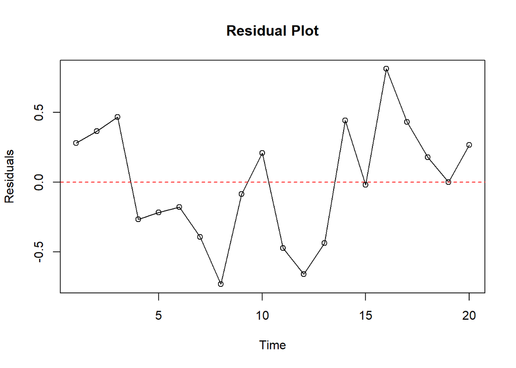

```r
# Non-Autokorelasi
plot(residuals(model1), type = "o", main = "Residual Plot", xlab = "Time", ylab = "Residuals")
abline(h = 0, lty = 2, col = "red")
```

```r
dwtest(model1)
```

```
##
##  Durbin-Watson test
##
## data:  model1
## DW = 1.1358, p-value = 0.009813
## alternative hypothesis: true autocorrelation is greater than 0
```

Berdasarkan Durbin Watson test diperoleh nilai DW sebesar 1.1358 dengan p value sebesar 0.009813. Karena p value < 0.05, maka tolak H0. Dengan demikian, terdapat autokorelasi positif pada residual. Nilai Durbin-Watson yang lebih kecil dari 2 juga mendukung adanya autokorelasi positif. Sehingga diperlukan penanganan khusus dengan metode Cochrane-Orcutt dan Hildreth-Lu.

# Penanganan Autokorelasi (Cochrane-Orcutt)

```r
model1CO <- cochrane.orcutt(model1)
model1CO
```

```
## Cochrane-orcutt estimation for first order autocorrelation
##
## Call:
## lm(formula = `Market share` ~ Price, data = data1)
##
##  number of interaction: 8
##  rho 0.425232
##
## Durbin-Watson statistic
## (original):    1.13582 , p-value: 9.813e-03
## (transformed): 1.95804 , p-value: 4.151e-01
##
##  coefficients:
## (Intercept)       Price
##    26.72209   -24.08413
```

```r
# Rho optimum
rho <- model1CO$rho
rho
```

```
## [1] 0.4252321
```

# Transformasi Manual

```r
# Transformasi Cochrane-Orcutt secara manual
marketshare.trans <- data1$`Market share`[-1] -
                     data1$`Market share`[-length(data1$`Market share`)] * rho

price.trans <- data1$Price[-1] -
               data1$Price[-length(data1$Price)] * rho

# Model setelah transformasi
model1COmanual <- lm(marketshare.trans ~ price.trans)

summary(model1COmanual)
```

```
##
## Call:
## lm(formula = marketshare.trans ~ price.trans)
##
## Residuals:
##      Min       1Q   Median       3Q      Max
## -0.55508 -0.25069 -0.05506  0.25007  0.83017
##
## Coefficients:
##             Estimate Std. Error t value Pr(>|t|)
## (Intercept)  15.3590     0.9385   16.36 7.71e-12 ***
## price.trans -24.0841     1.9385  -12.42 5.90e-10 ***
## ---
## Signif. codes:  0 '***' 0.001 '**' 0.01 '*' 0.05 '.' 0.1 ' ' 1
##
## Residual standard error: 0.3955 on 17 degrees of freedom
## Multiple R-squared:  0.9008, Adjusted R-squared:  0.895
## F-statistic: 154.4 on 1 and 17 DF,  p-value: 5.903e-10
```

```r
b0bintang <- model1COmanual$coefficients[-2]
b0 <- b0bintang/(1-rho)
b0
```

```
## (Intercept)
##    26.72209
```

```r
b1 <- model1COmanual$coefficients[-1]
b1
```

```
## price.trans
##   -24.08413
```

# Penanganan Autokorelasi (Hildreth-Lu)

```r
library(HoRM)
```

```r
#Penanganan Autokorelasi Hildreth lu
# Hildreth-Lu
hildreth.lu.func<- function(r, model1){
  x <- model.matrix(model1)[,-1]
  y <- model.response(model.frame(model1))
  n <- length(y)
  t <- 2:n
  y <- y[t]-r*y[t-1]
  x <- x[t]-r*x[t-1]

  return(lm(y~x))
}

#Pencariab rho yang meminimumkan SSE
r <- c(seq(0.1,0.9, by= 0.1))
tab <- data.frame("rho" = r, "SSE" = sapply(r, function(i){deviance(hildreth.lu.func(i, model1))}))
round(tab, 4)
```

```
##   rho    SSE
## 1 0.1 2.9791
## 2 0.2 2.8105
## 3 0.3 2.7052
## 4 0.4 2.6612
## 5 0.5 2.6749
## 6 0.6 2.7420
## 7 0.7 2.8588
## 8 0.8 3.0265
## 9 0.9 3.2529
```

```r
#Rho optimal di sekitar
rOpt <- seq(0.3,0.6, by= 0.001)
tabOpt <- data.frame("rho" = rOpt, "SSE" = sapply(rOpt, function(i){deviance(hildreth.lu.func(i, model1))}))
head(tabOpt[order(tabOpt$SSE),])
```

```
##       rho      SSE
## 126 0.425 2.659368
## 127 0.426 2.659370
## 125 0.424 2.659372
## 128 0.427 2.659377
## 124 0.423 2.659382
## 129 0.428 2.659390
```

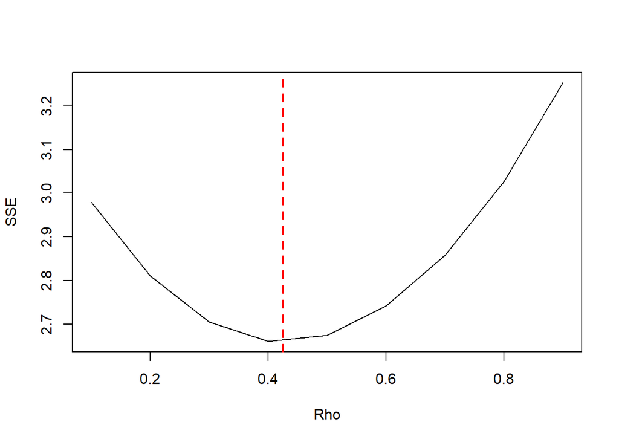

```r
#Grafik SSE optimum
par(mfrow = c(1,1))
plot(tab$SSE ~ tab$rho , type = "l", xlab = "Rho", ylab = "SSE")
abline(v = tabOpt[tabOpt$SSE==min(tabOpt$SSE),"rho"], lty = 2, col="red",lwd=2)
text(x=0.341, y=0.2397500, labels = "rho=0.341", cex = 0.8)
```

```r
#Model terbaik
model1HL <- hildreth.lu.func(0.425, model1)
summary(model1HL)
```

```
##
## Call:
## lm(formula = y ~ x)
##
## Residuals:
##      Min       1Q   Median       3Q      Max
## -0.55517 -0.25066 -0.05505  0.25010  0.83017
##
## Coefficients:
##             Estimate Std. Error t value Pr(>|t|)
## (Intercept)  15.3655     0.9387   16.37 7.68e-12 ***
## x           -24.0848     1.9380  -12.43 5.88e-10 ***
## ---
## Signif. codes:  0 '***' 0.001 '**' 0.01 '*' 0.05 '.' 0.1 ' ' 1
##
## Residual standard error: 0.3955 on 17 degrees of freedom
## Multiple R-squared:  0.9008, Adjusted R-squared:  0.895
## F-statistic: 154.4 on 1 and 17 DF,  p-value: 5.88e-10
```

```r
#Transformasi Balik
cat("y = ", coef(model1HL)[1]/(1-0.425), "+", coef(model1HL)[2],"x", sep = "")
```

```
## y = 26.72268+-24.08484x
```

```r
#Deteksi autokorelasi
dwtest(model1HL)
```

```
##
##  Durbin-Watson test
##
## data:  model1HL
## DW = 1.9577, p-value = 0.4148
## alternative hypothesis: true autocorrelation is greater than 0
```

Berdasarkan uji Durbin Watson setelah dilakukan penanganan autokorelasi menggunakan metode Hildreth Lu, diperoleh nilai DW sebesar 1.9577 dengan p value sebesar 0.4148. Karena p value > 0.05, maka gagal tolak H0, sehingga tidak terdapat bukti yang cukup adanya autokorelasi positif pada residual. Nilai DW yang mendekati 2 juga menunjukkan bahwa residual cenderung tidak mengalami autokorelasi sehingga, asumsi adanya non autokorelasi telah terpenuhi setelah dilakukan penanganan menggunakan metode Hildreth Lu.

```r
#Perbandingan Metode Penanganan Autokorelasi
sse <- c(`model awal` = deviance(model1), `Cochrane.Orcutt` = deviance(model1COmanual), `Hildreth.Lu` = deviance(model1HL))

n <- length(data1$`Market share`)
mse <- sse/n

akurasi <- rbind(SSE = sse, MSE = mse)
akurasi
```

```
##     model awal Cochrane.Orcutt Hildreth.Lu
## SSE  3.3082574       2.6593681   2.6593683
## MSE  0.1654129       0.1329684   0.1329684
```

Berdasarkan perbandingan nilai SSE dan MSE, model awal memiliki nilai SSE sebesar 3,3082574 dan MSE sebesar 0,1654129. Setelah dilakukan penanganan autokorelasi, nilai SSE dan MSE menurun menjadi 2,6593681 dan 0,1329684 pada metode Cochrane–Orcutt serta 2,6593683 dan 0,1329684 pada metode Hildreth–Lu. Hal ini menunjukkan bahwa kedua metode mampu menurunkan galat pada model dibandingkan model awal. Berdasarkan nilai SSE, Cochrane–Orcutt menghasilkan nilai yang sedikit lebih kecil dibandingkan Hildreth–Lu, tetapi perbedaannya sangat kecil. Selain itu, kedua metode menghasilkan nilai Durbin-Watson yang mendekati 2 dengan p-value > 0,05, sehingga keduanya berhasil menangani masalah autokorelasi. Dengan demikian, Cochrane–Orcutt dan Hildreth–Lu memiliki kinerja yang hampir sama, dengan Cochrane–Orcutt sedikit lebih baik berdasarkan SSE.

# Data 2 - Sales Advertising

```r
data2 <- read_excel("D:/IPB/PPT Kuliah - IPB/Semester 5 Dept Statistika/MPDW/Dataset/Dataset Praktikum 2.xlsx",sheet = "Sales")
data2
```

```
## # A tibble: 40 × 3
##     Year Sales Advertising
##    <dbl> <dbl>       <dbl>
##  1  1975  11.7         9.4
##  2  1976  12           9.6
##  3  1977  12.3        10
##  4  1978  12.8        10.4
##  5  1979  13.1        10.8
##  6  1980  13.6        10.9
##  7  1981  13.9        11.7
##  8  1982  14.4        12.2
##  9  1983  14.7        12.5
## 10  1984  15.3        12.9
## # ℹ 30 more rows
```

# Eksplorasi Data

```r
# Summary
summary(data2)
```

```
##       Year          Sales        Advertising
##  Min.   :1975   Min.   :11.70   Min.   : 9.40
##  1st Qu.:1985   1st Qu.:15.45   1st Qu.:12.97
##  Median :1994   Median :17.90   Median :15.90
##  Mean   :1994   Mean   :17.13   Mean   :15.72
##  3rd Qu.:2004   3rd Qu.:19.30   3rd Qu.:18.55
##  Max.   :2014   Max.   :21.00   Max.   :22.10
```

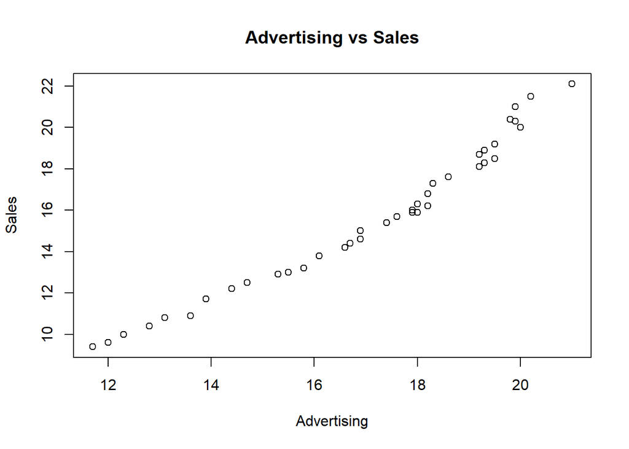

```r
# Scatterplot
plot(data2$Sales, data2$`Advertising`, main = "Advertising vs Sales", xlab = "Advertising", ylab = "Sales")
```

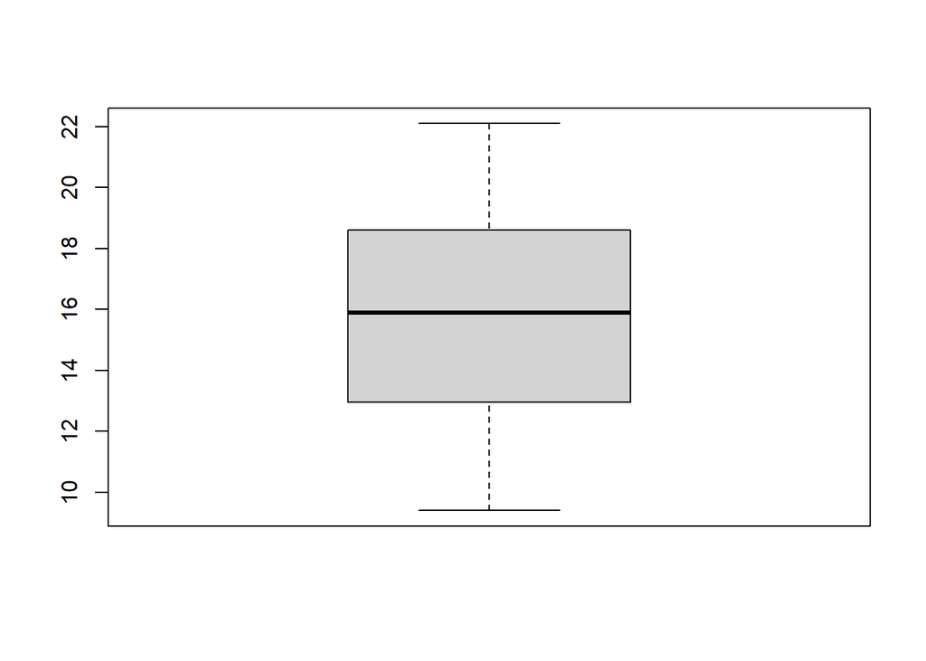

```r
# Boxplot
## Boxplot Advertising
boxplot(data2$`Advertising`)
```

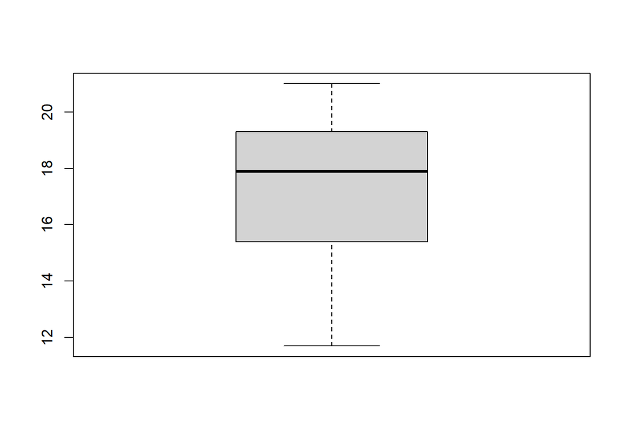

```r
## Boxplot Sales
boxplot(data2$Sales)
```

# Model Regresi

```r
model2 <- lm(Sales ~ Advertising, data = data2)
summary(model2)
```

```
##
## Call:
## lm(formula = Sales ~ Advertising, data = data2)
##
## Residuals:
##      Min       1Q   Median       3Q      Max
## -1.03758 -0.40343  0.08933  0.45674  0.74036
##
## Coefficients:
##             Estimate Std. Error t value Pr(>|t|)
## (Intercept)  5.96513    0.38092   15.66   <2e-16 ***
## Advertising  0.71035    0.02365   30.04   <2e-16 ***
## ---
## Signif. codes:  0 '***' 0.001 '**' 0.01 '*' 0.05 '.' 0.1 ' ' 1
##
## Residual standard error: 0.527 on 38 degrees of freedom
## Multiple R-squared:  0.9596, Adjusted R-squared:  0.9585
## F-statistic: 902.3 on 1 and 38 DF,  p-value: < 2.2e-16
```

Berdasarkan hasil di atas, diketahui bahwa terdapat persamaan regresi Sales = 5.965 + 0.710 (Advertising), yang artinya ketika Advertising mengalami kenaikan sebesar satu satuan, maka Sales akan meningkat sebesar 0.710 satuan, dengan asumsi faktor-faktor lainnya yang tidak termasuk ke dalam model dianggap konstan. Sehingga, ketika Advertising semakin tinggi, maka Sales cenderung semakin tinggi. Kemudian, berdasarkan p value Advertising < 2 × 10^-16, yang lebih kecil dari 0.05, maka tolak H0, yang artinya Advertising berpengaruh secara signifikan terhadap Sales. Selanjutnya, diperoleh nilai R-squared sebesar 0.9596 atau 95.96%, yang berarti variasi Sales dapat dijelaskan oleh Advertising dalam model regresi, sedangkan sisanya sebesar 4.04% variasi Sales dapat dijelaskan oleh faktor lain yang tidak masuk ke dalam model beserta dengan galatnya. Hasil uji F juga menunjukkan bahwa model regresi secara keseluruhan adalah signifikan, dengan nilai F-statistic sebesar 902.3 dan p-value < 2.2 × 10^-16. Dengan demikian, model regresi yang melibatkan Advertising secara keseluruhan signifikan dalam menjelaskan variasi Sales.

# Uji Asumsi

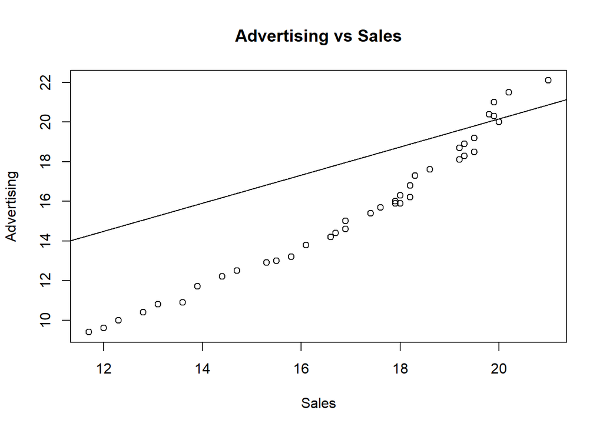

```r
# Linearitas
plot(data2$Sales, data2$Advertising, xlab = "Sales", ylab = "Advertising", main = "Advertising vs Sales")
abline(model2)
```

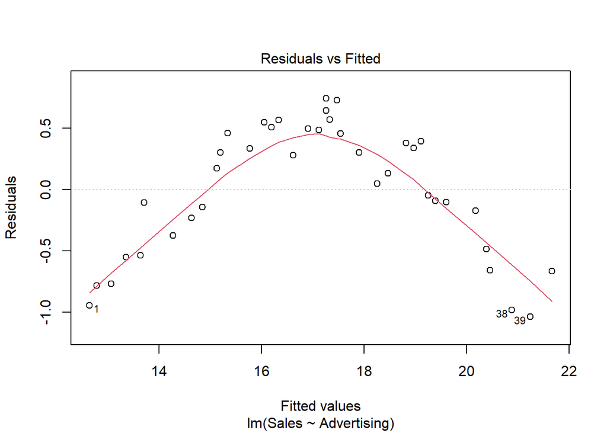

```r
plot(model2, which = 1)
```

Berdasarkan grafik Advertising vs Sales, terlihat adanya hubungan positif antara Advertising dan Sales, yang menunjukkan bahwa peningkatan Advertising cenderung diikuti oleh peningkatan Sales. Hal ini sejalan dengan hasil analisis regresi yang menunjukkan koefisien Advertising bernilai positif sebesar 0.710 dan nilai R-square sebesar 95.96%. Selanjutnya, berdasarkan grafik Residuals vs Fitted, residual tidak menyebar secara acak di sekitar garis nol dan membentuk pola melengkung. Hal ini menunjukkan bahwa asumsi linearitas pada model regresi belum sepenuhnya terpenuhi.

```r
# Normalitas
shapiro.test(residuals(model2))
```

```
##
##  Shapiro-Wilk normality test
##
## data:  residuals(model2)
## W = 0.93205, p-value = 0.0188
```

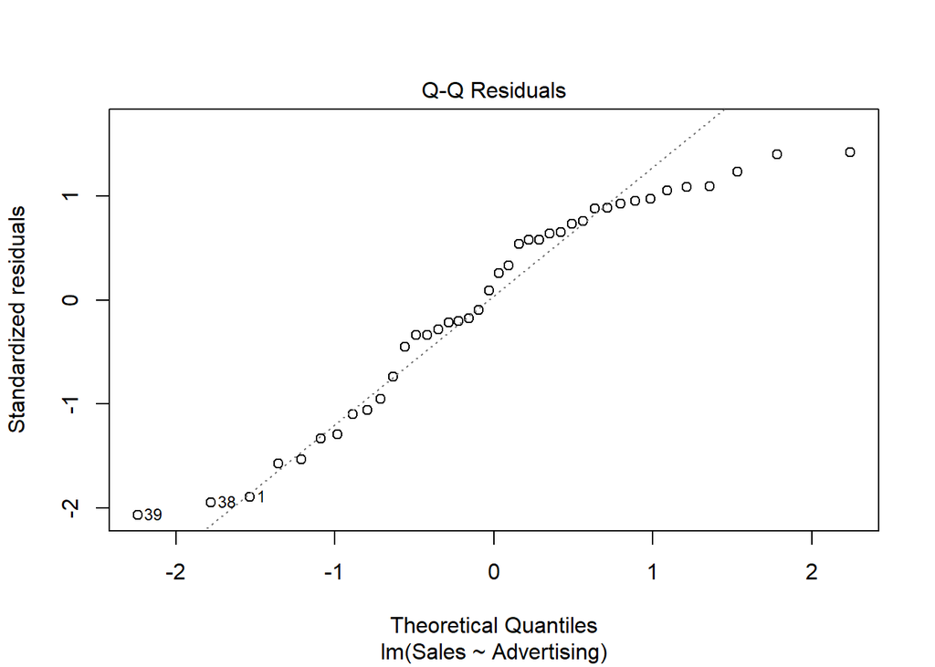

```r
plot(model2, which = 2)
```

Berdasarkan Shapiro Wilk test diperoleh p-value sebesar 0.0188 < 0.05, sehingga tolak H0 dan dapat disimpulkan bahwa residual tidak berdistribusi normal. Hal ini didukung oleh grafik Q-Q Residuals yang menunjukkan adanya penyimpangan titik-titik dari garis diagonal, terutama pada bagian ekor. Oleh karena itu, asumsi normalitas residual belum terpenuhi.

```r
# Homoskedastisitas
bptest(model2)
```

```
##
##  studentized Breusch-Pagan test
##
## data:  model2
## BP = 0.0037386, df = 1, p-value = 0.9512
```

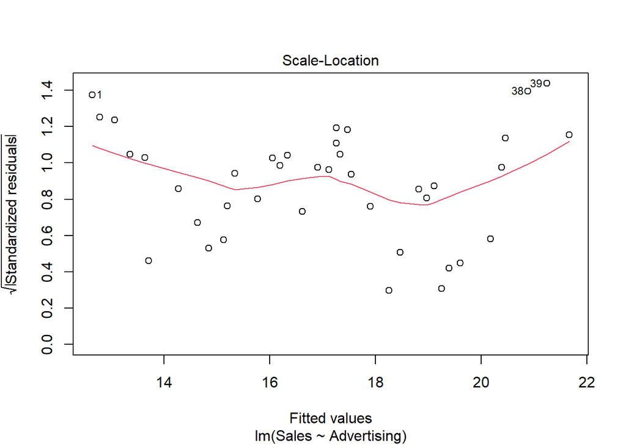

```r
plot(model2, which = 3)
```

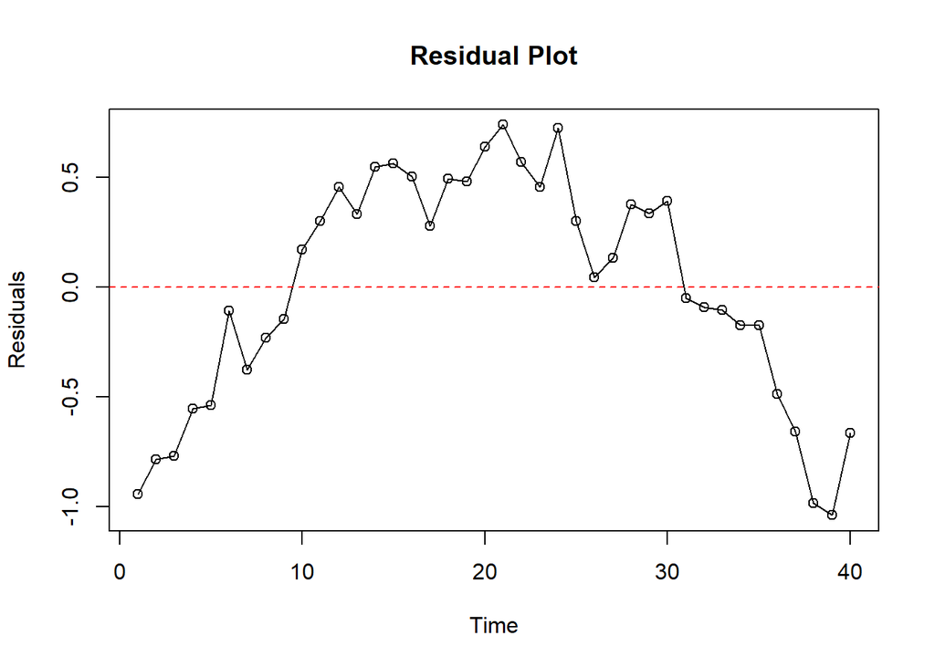

```r
# Non-Autokorelasi
plot(residuals(model2), type = "o", main = "Residual Plot", xlab = "Time", ylab = "Residuals")
abline(h = 0, lty = 2, col = "red")
```

```r
dwtest(model2)
```

```
##
##  Durbin-Watson test
##
## data:  model2
## DW = 0.16204, p-value < 2.2e-16
## alternative hypothesis: true autocorrelation is greater than 0
```

Berdasarkan Durbin Watson test diperoleh nilai DW = 0.16204 dengan p-value < 2.2 × 10^-16. Karena p-value < 0.05, maka tolak H0, yang berarti terdapat autokorelasi positif pada residual. Dengan demikian, asumsi independensi residual tidak terpenuhi. Sehingga, diperlukan penanganan untuk mengatas permasalahan tersebut dengan metode Cochrane-Orcutt dan Hildreth-Lu.

# Penanganan Autokorelasi (Cochrane-Orcutt)

```r
model2CO <- cochrane.orcutt(model2)
model2CO
```

```
## Cochrane-orcutt estimation for first order autocorrelation
##
## Call:
## lm(formula = Sales ~ Advertising, data = data2)
##
##  number of interaction: 39
##  rho 0.903123
##
## Durbin-Watson statistic
## (original):    0.16204 , p-value: 8.935e-20
## (transformed): 1.93925 , p-value: 3.78e-01
##
##  coefficients:
## (Intercept) Advertising
##   10.252375    0.488489
```

```r
# Rho optimum
rho <- model2CO$rho
rho
```

```
## [1] 0.9031233
```

Berdasarkan metode Cochrane-Orcutt, diperoleh nilai rho = 0.903123, yang menunjukkan adanya autokorelasi positif yang kuat pada model awal. Nilai Durbin-Watson sebelum transformasi sebesar 0.16204 dengan p-value 8.935 × 10^-20 < 0.05, sehingga terdapat autokorelasi positif. Setelah dilakukan transformasi Cochrane-Orcutt, nilai Durbin-Watson meningkat menjadi 1.93925 dengan p-value 0.378 > 0.05. Dengan demikian, autokorelasi telah berhasil diatasi setelah transformasi.

# Transformasi Manual

```r
Advertising.trans <- data2$Advertising[-1] - data2$Advertising[-40] * rho
Sales.trans <- data2$Sales[-1] - data2$Sales[-40] * rho

model2COmanual <- lm(Sales.trans ~ Advertising.trans)
summary(model2COmanual)
```

```
##
## Call:
## lm(formula = Sales.trans ~ Advertising.trans)
##
## Residuals:
##      Min       1Q   Median       3Q      Max
## -0.37730 -0.14957  0.01257  0.10464  0.45315
##
## Coefficients:
##                   Estimate Std. Error t value Pr(>|t|)
## (Intercept)        0.99322    0.14141   7.023 2.64e-08 ***
## Advertising.trans  0.48849    0.07543   6.476 1.43e-07 ***
## ---
## Signif. codes:  0 '***' 0.001 '**' 0.01 '*' 0.05 '.' 0.1 ' ' 1
##
## Residual standard error: 0.1868 on 37 degrees of freedom
## Multiple R-squared:  0.5313, Adjusted R-squared:  0.5186
## F-statistic: 41.94 on 1 and 37 DF,  p-value: 1.426e-07
```

```r
b0bintang <- model2COmanual$coefficients[-2]
b0 <- b0bintang/(1-rho)
b0
```

```
## (Intercept)
##    10.25237
```

```r
b1 <- model2COmanual$coefficients[-1]
b1
```

```
## Advertising.trans
##         0.4884891
```

# Penanganan Autokorelasi (Hildreth-Lu)

```r
library(HoRM)
```

```r
#Penanganan Autokorelasi Hildreth lu
# Hildreth-Lu
hildreth.lu.func<- function(r, model2){
  x <- model.matrix(model2)[,-1]
  y <- model.response(model.frame(model2))
  n <- length(y)
  t <- 2:n
  y <- y[t]-r*y[t-1]
  x <- x[t]-r*x[t-1]

  return(lm(y~x))
}

#Pencarian rho yang meminimumkan SSE
r <- c(seq(0.1,0.9, by= 0.1))
tab <- data.frame("rho" = r, "SSE" = sapply(r, function(i){deviance(hildreth.lu.func(i, model2))}))
round(tab, 4)
```

```
##   rho    SSE
## 1 0.1 7.8457
## 2 0.2 6.3303
## 3 0.3 5.0154
## 4 0.4 3.9007
## 5 0.5 2.9856
## 6 0.6 2.2692
## 7 0.7 1.7494
## 8 0.8 1.4226
## 9 0.9 1.2914
```

Pertama-tama akan dicari di mana kira-kira nilai ρ yang menghasilkan SSE minimum. Berdasarkan hasil di atas, terlihat bahwa nilai SSE terus menurun seiring dengan bertambahnya nilai ρ, sehingga SSE minimum diperoleh ketika ρ = 0.9, yaitu sebesar 1.2914. Namun, hasil tersebut masih kurang teliti karena nilai ρ yang digunakan memiliki jarak antar nilai sebesar 0.1. Oleh karena itu, akan dicari kembali nilai ρ yang lebih optimum dengan tingkat ketelitian yang lebih tinggi. Jika sebelumnya jarak antar ρ yang dicari adalah 0.1, kali ini jarak antar ρ akan dibuat menjadi 0.001 sehingga dapat diperoleh nilai ρ yang menghasilkan SSE minimum dengan lebih teliti.

```r
#Rho optimal di sekitar
rOpt <- seq(0.75,0.99, by= 0.001)
tabOpt <- data.frame("rho" = rOpt, "SSE" = sapply(rOpt, function(i){deviance(hildreth.lu.func(i, model2))}))
head(tabOpt[order(tabOpt$SSE),])
```

```
##       rho      SSE
## 154 0.903 1.291226
## 155 0.904 1.291239
## 153 0.902 1.291248
## 156 0.905 1.291289
## 152 0.901 1.291304
## 157 0.906 1.291375
```

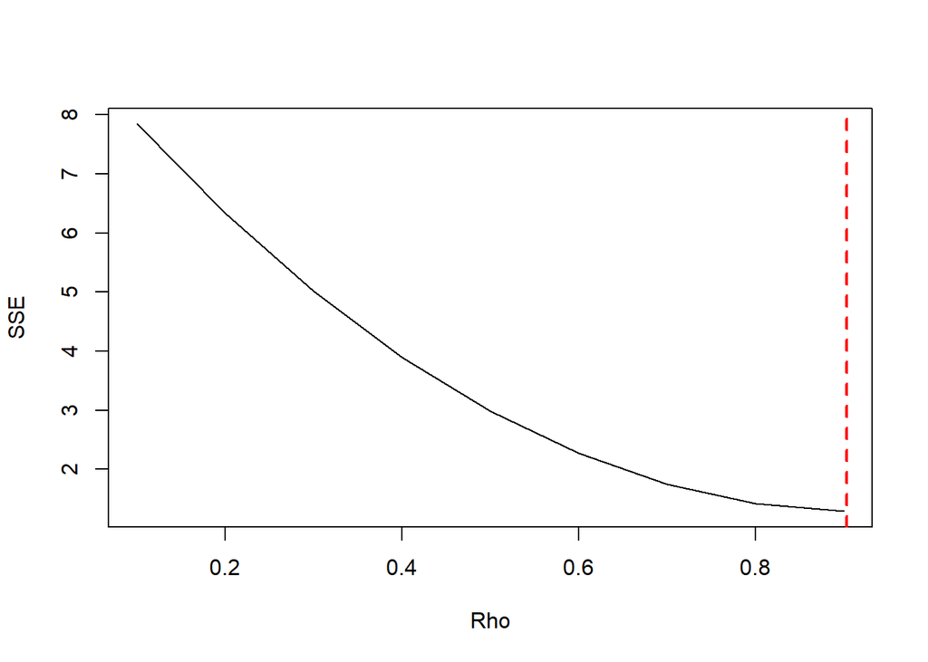

```r
#Grafik SSE optimum
par(mfrow = c(1,1))
plot(tab$SSE ~ tab$rho , type = "l", xlab = "Rho", ylab = "SSE")
abline(v = tabOpt[tabOpt$SSE==min(tabOpt$SSE),"rho"], lty = 2, col="red",lwd=2)
text(x=0.341, y=0.2397500, labels = "rho=0.341", cex = 0.1)
```

Perhitungan yang dilakukan menggunakan aplikasi R menunjukkan bahwa nilai ρ optimum, yaitu nilai ρ yang menghasilkan SSE terkecil, terdapat pada ρ = 0.903 dengan nilai SSE sebesar 1.291226. Hal tersebut juga ditunjukkan pada plot pencarian nilai ρ. Selanjutnya, model dapat diperoleh dengan mengevaluasi nilai ρ = 0.903, kemudian dilanjutkan dengan pengujian autokorelasi menggunakan uji Durbin-Watson. Setelah diperoleh model hasil transformasi dan dilakukan pengujian autokorelasi, koefisien regresi hasil transformasi tersebut perlu digunakan untuk melakukan transformasi balik.

```r
#Model terbaik
model2HL <- hildreth.lu.func(0.903, model2)
summary(model2HL)
```

```
##
## Call:
## lm(formula = y ~ x)
##
## Residuals:
##      Min       1Q   Median       3Q      Max
## -0.37720 -0.14949  0.01266  0.10464  0.45301
##
## Coefficients:
##             Estimate Std. Error t value Pr(>|t|)
## (Intercept)  0.99401    0.14144   7.028 2.60e-08 ***
## x            0.48869    0.07536   6.485 1.39e-07 ***
## ---
## Signif. codes:  0 '***' 0.001 '**' 0.01 '*' 0.05 '.' 0.1 ' ' 1
##
## Residual standard error: 0.1868 on 37 degrees of freedom
## Multiple R-squared:  0.532,  Adjusted R-squared:  0.5193
## F-statistic: 42.05 on 1 and 37 DF,  p-value: 1.39e-07
```

```r
#Transformasi Balik
cat("y = ", coef(model2HL)[1]/(1-0.903), "+", coef(model2HL)[2],"x", sep = "")
```

```
## y = 10.24749+0.4886925x
```

```r
#Deteksi autokorelasi
dwtest(model2HL)
```

```
##
##  Durbin-Watson test
##
## data:  model2HL
## DW = 1.9393, p-value = 0.378
## alternative hypothesis: true autocorrelation is greater than 0
```

Berdasarkan uji Durbin-Watson setelah dilakukan penanganan autokorelasi menggunakan metode Hildreth-Lu, diperoleh nilai DW sebesar 1.9393 dengan p-value sebesar 0.378. Karena p-value > 0.05, maka gagal tolak H0, sehingga tidak terdapat bukti yang cukup adanya autokorelasi positif pada residual. Nilai DW yang mendekati 2 juga menunjukkan bahwa residual cenderung tidak mengalami autokorelasi. Dengan demikian, asumsi non-autokorelasi telah terpenuhi setelah dilakukan penanganan menggunakan metode Hildreth-Lu.

```r
#Perbandingan Metode Penanganan Autokorelasi
sse <- c(`model awal` = deviance(model2), `Cochrane.Orcutt` = deviance(model2COmanual), `Hildreth.Lu` = deviance(model2HL))

n <- length(data2$Sales)
mse <- sse/n

akurasi <- rbind(SSE = sse, MSE = mse)
akurasi
```

```
##     model awal Cochrane.Orcutt Hildreth.Lu
## SSE 10.5545322      1.29122545  1.29122572
## MSE  0.2638633      0.03228064  0.03228064
```

Berdasarkan perbandingan nilai SSE dan MSE, model awal memiliki nilai SSE sebesar 10.5545322 dan MSE sebesar 0.2638633. Setelah dilakukan penanganan autokorelasi, nilai SSE dan MSE menurun menjadi 1.29122545 dan 0.03228064 pada metode Cochrane–Orcutt, serta 1.29122572 dan 0.03228064 pada metode Hildreth–Lu. Penurunan nilai SSE dan MSE tersebut menunjukkan bahwa kedua metode mampu mengurangi galat pada model dibandingkan dengan model awal. Pada hal ini metode terbaiknya berdasarkan nilai SSE terkecil ada pada metode Cochrane.Orcutt walaupun hanya berbeda sangat kecil dengan metode Hildreth.Lu.